# An intro stats narrative: The can-you-tell-it’s-AI scenario

Proportions of successes, binomials, and the null train-of-thought

Evangeline Reynolds

2026-08-07

This is adapted from [Buzz and Doris Dolphins eval](https://evamaerey.github.io/mytidytuesday/2026-05-04-ggttest-ggram/intro-stats-narrative.html)

We started thinking about formal **statistical** tests (‘**hypothesis testing**’) first with case of ~the friendly **dolphins** Doris and Buzz~. Trainers run an experiment with the two dolphins in a large tank. Buzz is facing one side where the trainer indicates which way Doris will needs to go (right or left) to get a **fish** prize from another trainer. Buzz and Doris are separated by a large, curtain so we know that Doris cannot see what Buzz’s trainer has indicated (but the trainers *are* able to **communicate** and settle on a fish-treat direction).

```r
library(tidyverse)
library(ggprop.test)
set_theme(theme_grey(base_size = 14) + theme(panel.grid = element_blank()))

curry_bot_or_not <- create_prop_data(failure = "incorrect",
                 success = "correct",
                 num_failure = 0,
                 num_success = 6)

curry_bot_or_not
```

```
## # A tibble: 6 × 1
##   outcome
##   <fct>
## 1 correct
## 2 correct
## 3 correct
## 4 correct
## 5 correct
## 6 correct
```

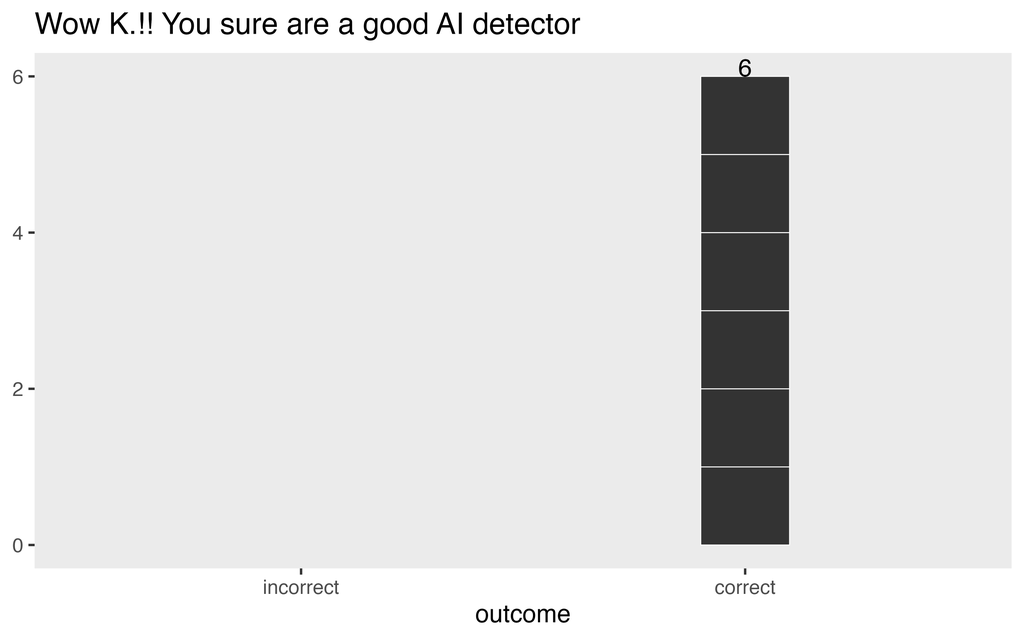

```r
curry_bot_or_not |>
  ggplot() +
  aes(x = outcome) +
  geom_stack() +
  geom_stack_label() +
  labs(title = "Wow K.!! You sure are a good AI detector")
```

[figure not shown]

```r
last_plot() +
  annotate(geom = "text",  # using a text layer, but not looking at the data ...
           x = I(.2),
           y = I(.75),
           label = "🤖or🧑",
           angle = 25,
           size = 18)
```

To look how consistent the outcome 6/6 fish with a chance model, we’ll use the logic of the ‘Prop test’, or one-sample proportion test.

### Proportion as balancing point…

The very first step to tackling this problem is just to calculate the **observed statistic**, in this case, the **proportion** $\hat{p}$ of successes.

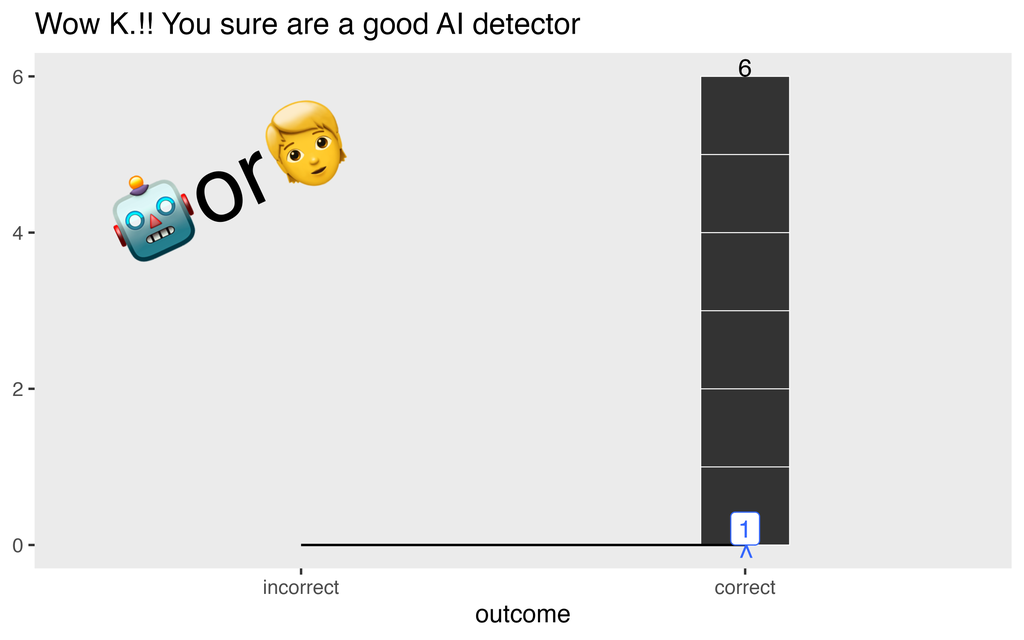

```r
last_plot() +
  geom_support() +
  geom_prop() +
  geom_prop_label()
```

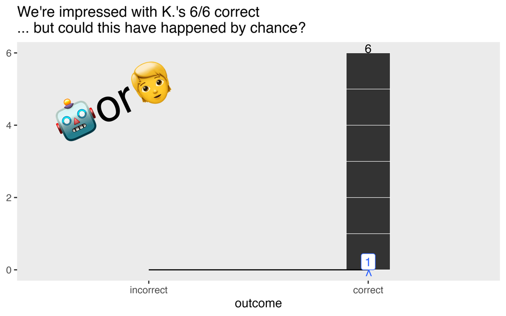

```r
last_plot() +
  labs(title = "We're impressed with K.'s 6/6 correct \n... but could this have happened by chance?")
```

And by ‘chance’ we mean guessing, a 50-50 propensity to go to either side, no matter what Buzz and his trainer have going on. Let’s place the asserted proportion of .5 as a contrast in our figure:

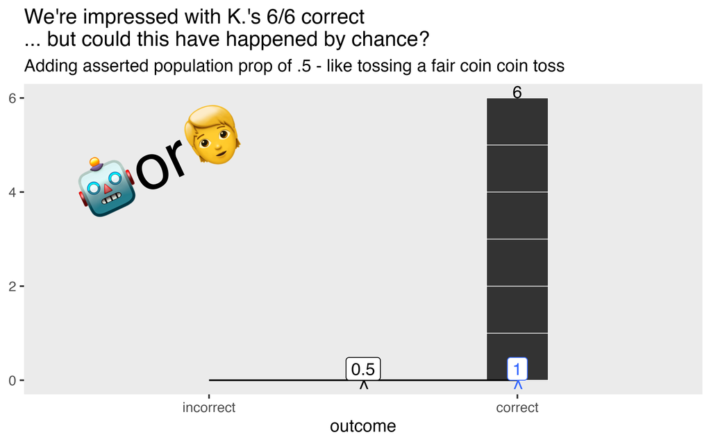

```r
last_plot() +
  stamp_prop(.5) +
  stamp_prop_label(.5) +
  labs(subtitle = "Adding asserted population prop of .5 - like tossing a fair coin coin toss")
```

### Simulating outcomes

And let’s ‘toss some coins’. If we do 6 coin tosses, we can see a real one-time outcome of what happens just by chance (say heads is a ‘success’), and associated proportion for 6 50-50 chance trials!

```r
curry_bot_or_not |>
  mutate(synthetic =
           to_synthetic(outcome, prob = .5))
```

```
## # A tibble: 6 × 2
##   outcome synthetic
##   <fct>   <fct>
## 1 correct correct
## 2 correct correct
## 3 correct incorrect
## 4 correct correct
## 5 correct correct
## 6 correct correct
```

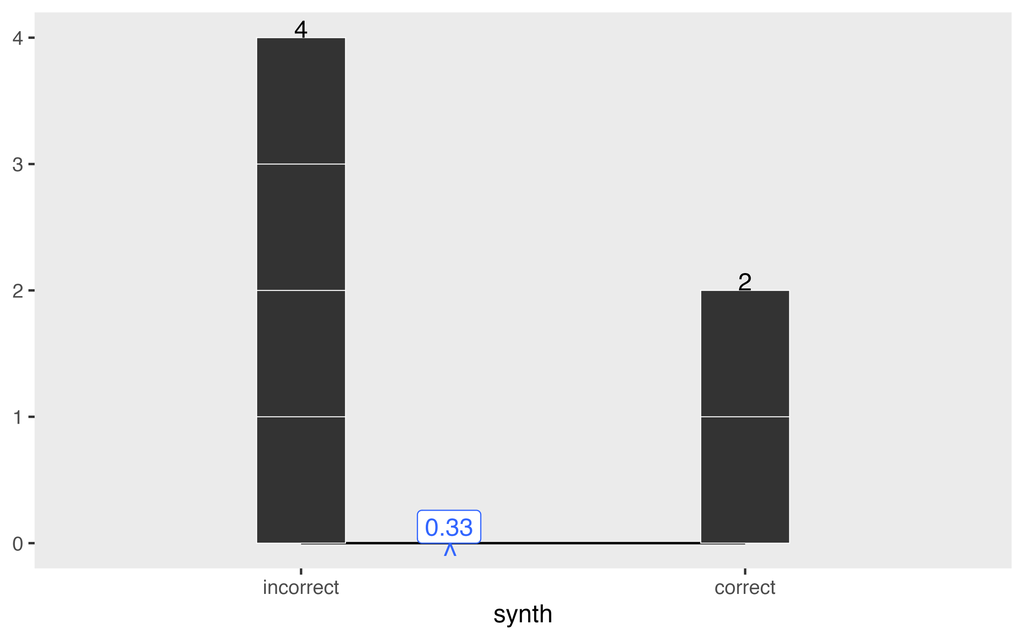

```r
curry_bot_or_not |>
  mutate(synth =
           to_synthetic(outcome, prob = .5)) |>
  ggplot() +
  aes(x = synth) +
  geom_support() +
  geom_stack() +
  geom_stack_label() +
  geom_prop() +
  geom_prop_label()
```

Let’s do 6 more tosses, and again calculate the proportion.

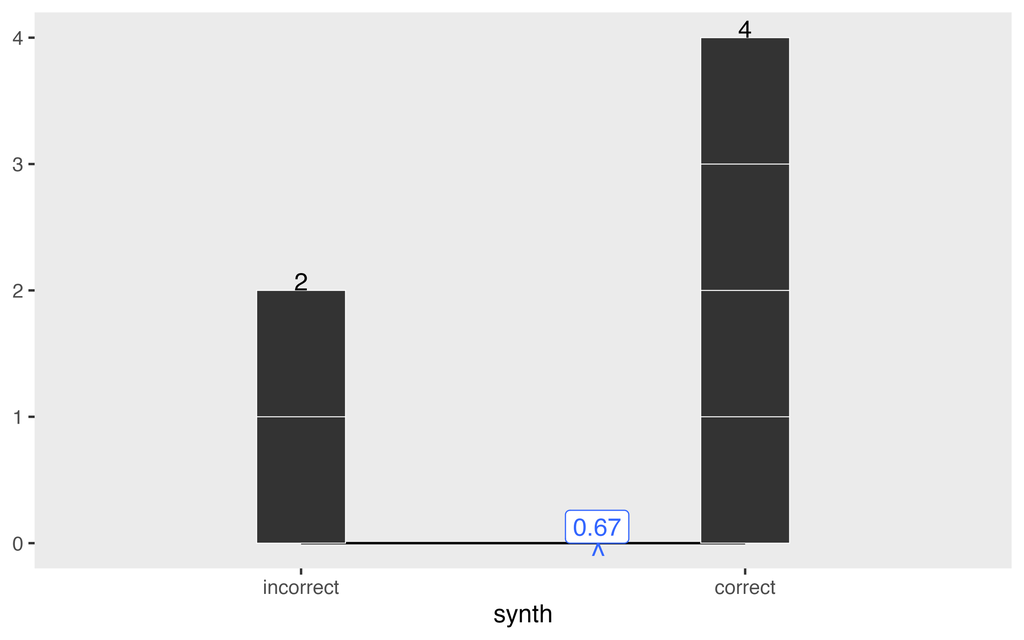

```r
last_plot() + curry_bot_or_not |> mutate(synth = to_synthetic(outcome, prob = .5))
```

Let’s do 6 more tosses, and calculate the proportion heads.

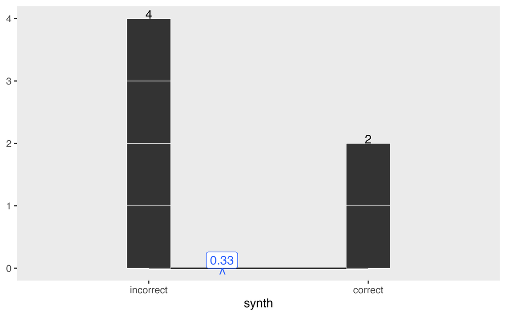

```r
last_plot() + curry_bot_or_not |> mutate(synth = to_synthetic(outcome, prob = .5))
```

Let’s do 6 more tosses, and calculate the proportion heads.

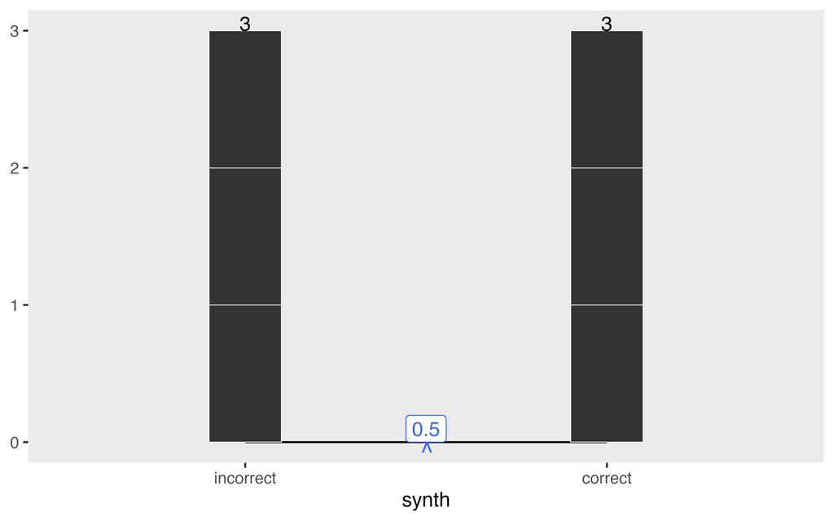

```r
last_plot() + curry_bot_or_not |> mutate(synth = to_synthetic(outcome, prob = .5))
```

Let’s do 6 more tosses, and calculate the proportion heads.

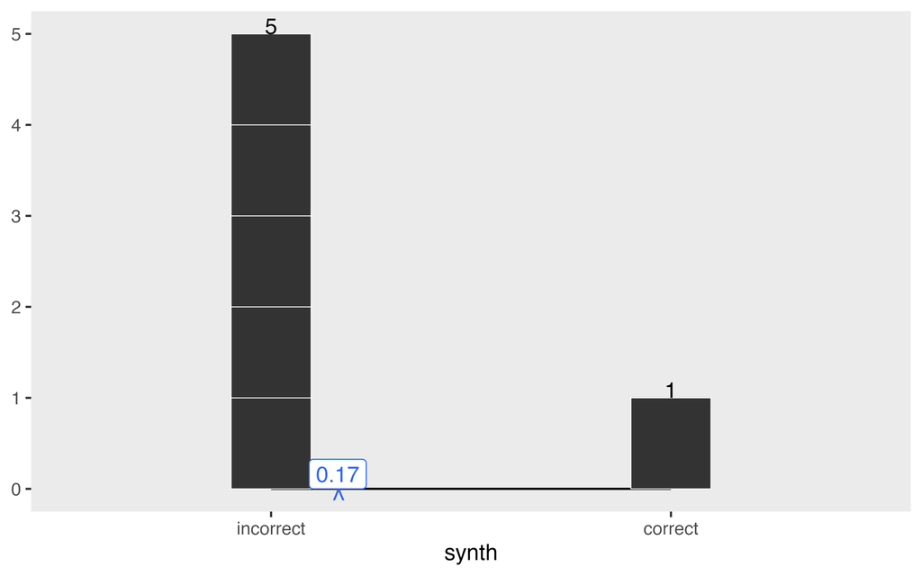

```r
last_plot() + curry_bot_or_not |> mutate(synth = to_synthetic(outcome, prob = .5))
```

### Analytic approach, chance model expectations via binomial dist

Alright, from these chance experiments, we might feel like we start to have footing to say that this Doris and Buzz’s experience isn’t consistent with chance.

> But… simulation is kind of a hassle - is there a more **analytic**, math-based approach, where I can just think about the proportion outcomes of a lot of 6 trial experiments?!!?

Yes! Since we are just looking at coin flips with precise **probabilistic** outcomes, we can use the a **binomial** distribution.

Let’s first look at the distribution associated with a single coin flip below. We’ll see that the proportion of successes can either by 1 or 0 - and there’s a 50-50 chance of either. It’s head or tails.

```r
tidy_dbinom(num_trials = 1, single_trial_prob = .5) |>
  mutate(prop = num_successes/num_trials)
```

```
## # A tibble: 2 × 5
##   num_successes probability single_trial_prob num_trials  prop
##           <int>       <dbl>             <dbl>      <dbl> <dbl>
## 1             0         0.5               0.5          1     0
## 2             1         0.5               0.5          1     1
```

For two coin flips, we start to see branching… We see that for proportions of successes, we can get TT tails-tails, both TH or HT (half successes), or HH (100% successes).

```r
tidy_dbinom(num_trials = 2, single_trial_prob = .5)
```

```
## # A tibble: 3 × 4
##   num_successes probability single_trial_prob num_trials
##           <int>       <dbl>             <dbl>      <dbl>
## 1             0        0.25               0.5          2
## 2             1        0.5                0.5          2
## 3             2        0.25               0.5          2
```

For three coin flips, we start see further branching …

```r
tidy_dbinom(num_trials = 3, single_trial_prob = .5)
```

```
## # A tibble: 4 × 4
##   num_successes probability single_trial_prob num_trials
##           <int>       <dbl>             <dbl>      <dbl>
## 1             0       0.125               0.5          3
## 2             1       0.375               0.5          3
## 3             2       0.375               0.5          3
## 4             3       0.125               0.5          3
```

```r
tidy_dbinom(num_trials = 4, single_trial_prob = .5)
```

```
## # A tibble: 5 × 4
##   num_successes probability single_trial_prob num_trials
##           <int>       <dbl>             <dbl>      <dbl>
## 1             0      0.0625               0.5          4
## 2             1      0.25                 0.5          4
## 3             2      0.375                0.5          4
## 4             3      0.25                 0.5          4
## 5             4      0.0625               0.5          4
```

Our cases is 6 trials… So there are 7 possible outcomes 0/6 to 6/6, and in this family of outcomes, the one that occurring most is 3/6 (50-50).

```r
tidy_dbinom(num_trials = 6, single_trial_prob = .5)
```

```
## # A tibble: 7 × 4
##   num_successes probability single_trial_prob num_trials
##           <int>       <dbl>             <dbl>      <dbl>
## 1             0      0.0156               0.5          6
## 2             1      0.0937               0.5          6
## 3             2      0.234                0.5          6
## 4             3      0.312                0.5          6
## 5             4      0.234                0.5          6
## 6             5      0.0937               0.5          6
## 7             6      0.0156               0.5          6
```

Let’s pop this on to our ‘balance’ picture! The heights of the distribution are proportional to the probability of occurance.

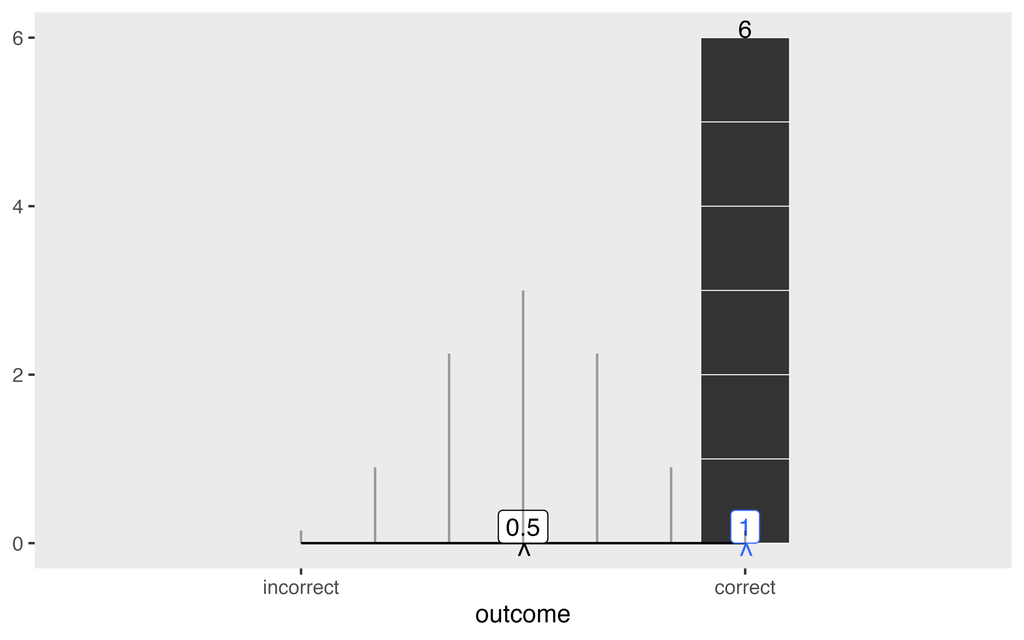

```r
curry_bot_or_not |>
  ggplot() +
  aes(x = outcome) +
  geom_stack() +
  geom_stack_label() +
  geom_support() +
  geom_prop() +
  geom_prop_label() +
  stamp_prop(.5) +
  stamp_prop_label(.5) +
  geom_binomial_null(.5)
```

### p-value

```r
tidy_dbinom(num_trials = 6,
            single_trial_prob = .5) |>
  filter(num_successes >= 6 |  # we'll look at as extreme as 6 successes
         num_successes <= 0)  # and on the other side 0 is as extreme
```

```
## # A tibble: 2 × 4
##   num_successes probability single_trial_prob num_trials
##           <int>       <dbl>             <dbl>      <dbl>
## 1             0      0.0156               0.5          6
## 2             6      0.0156               0.5          6
```

```r
2*(0.015625)  # 3 in 100 times! not too often!
```

```
## [1] 0.03125
```

$$H_0: \pi = .5$$

$$H_a: \pi ≠ .5$$

You may be thinking

> Hey, but I’ve heard of the “1 proportion Z test”. Isn’t z something in the normal distribution? And here we are using the binomial distribution.

But let’s look at another case where we do have enough data to use a trusty, well-behaved normal distribution and can speak of z-scores!

## End of prop test discussion… Some more gg extension-supported intro statistics ‘poems’.

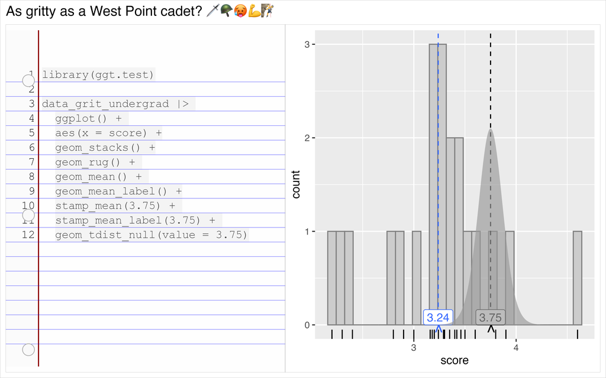

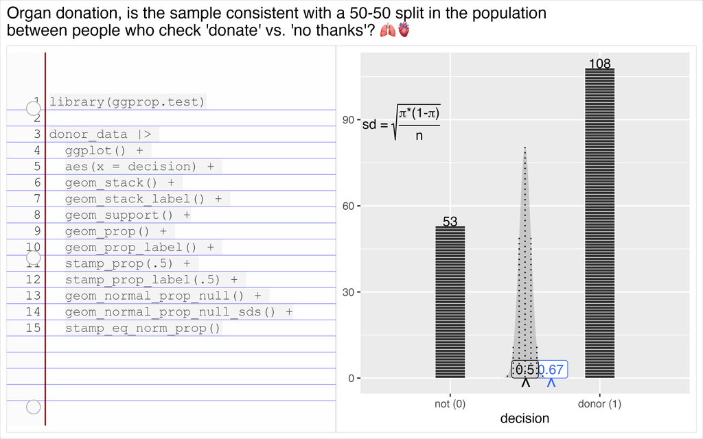

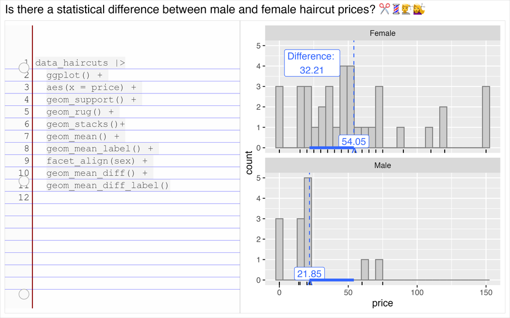

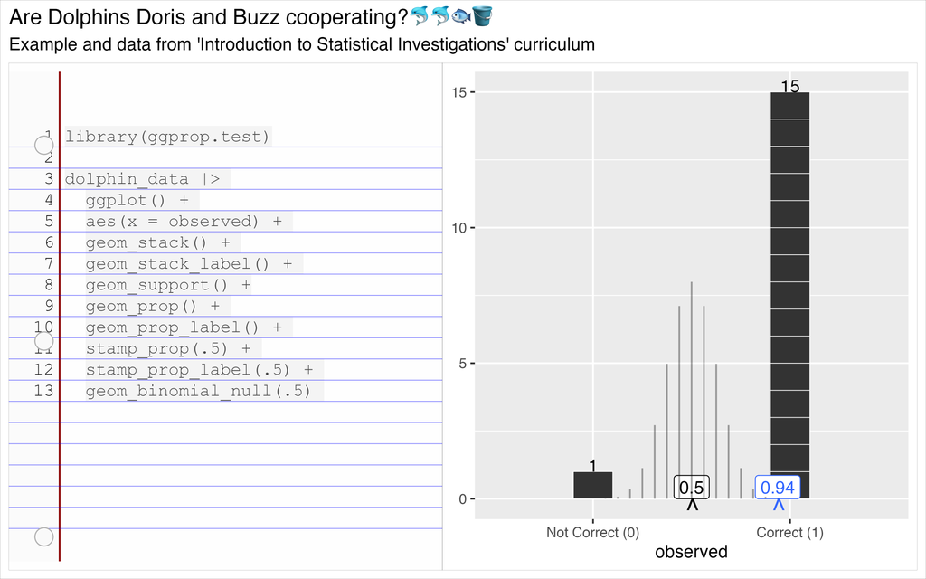